# Internships and Online Presence

Stat 365: Statistical Communication

## Wednesday, May 24th

Today we will…

- Finding internships & experiences
- Online Presence
- Build your Resume

## Where to find internships & experiences

- [Mustang Jobs](https://careerservices.calpoly.edu/explore-services/mustangjobs)
- [Student Opportunity Blog](https://calpolystats.blogspot.com/)
- [American Statistical Association JobWeb](https://www.amstat.org/your-career/asa-jobweb)
  - [Join the ASA](https://www.amstat.org/membership/become-a-member/membership-options?hkey=0301def8-92e1-4bf2-9aff-02959b3e61f5) for $25
- [Mathematical Sciences REUs (Research Experience for Undergrads)](https://www.nsf.gov/crssprgm/reu/list_result.jsp?unitid=5044)
- Summer Institute in Biostatistics (SIBS) Programs
- FROST Summer Research

## When to look for internships

- I encourage you to start looking as early as October for the following summer.
- Many REU/SIBS deadlines are in January/February.
- FROST applications happen at the end of Winter/early Spring Quarter.

Keep asking professors! Show them you are interested. If you bring them an idea, I am guessing most would be open to supervising.

## Reference Letter Writers

- Ask professors you feel know you well (or previous employers).
- Give them at least 2 weeks heads up.
- Provide them:
  - Resume
  - Link to job posting
  - Any additional relevant information

## Social Media

- LinkedIn
- Twitter
- [Mastodon](https://mastodon.social/explore)

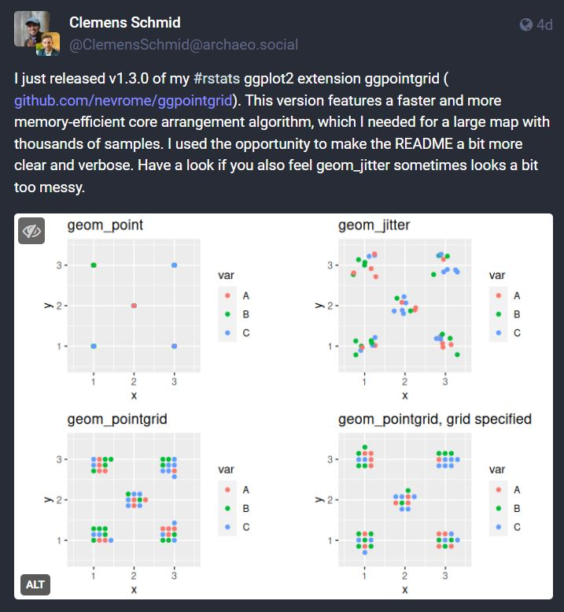

## Online Presence

[GitHub Pages](https://quarto.org/docs/publishing/github-pages.html)

- A “hacky” way to publish your projects online `xxx.github.io`.

[Personal Website](https://earobinson95.github.io/stat365-calpoly/98-grade-boosters/make-your-own-website.html)

## Personal Projects: Where to find data!

- [TidyTuesdays](https://github.com/rfordatascience/tidytuesday)
- [Makeover Mondays](https://www.makeovermonday.co.uk/data/)
- [Kaggle](https://www.kaggle.com/)

Create data visualizations, fit a statistical model, make predictions, tell a story with a dashboard!

> [#TidyTuesday](https://twitter.com/hashtag/TidyTuesday?src=hash&ref_src=twsrc%5Etfw) | Week 20 | Tornados  
> code: https://t.co/VC4y9GFHkC[#rstats](https://twitter.com/hashtag/rstats?src=hash&ref_src=twsrc%5Etfw) [#ggplot](https://twitter.com/hashtag/ggplot?src=hash&ref_src=twsrc%5Etfw) [#dataviz](https://twitter.com/hashtag/dataviz?src=hash&ref_src=twsrc%5Etfw) [pic.twitter.com/iHeyVjqND8](https://t.co/iHeyVjqND8)

> — Ryan Hart (@ryanahart) [May 20, 2023](https://twitter.com/ryanahart/status/1659868614579609606?ref_src=twsrc%5Etfw)

# [Build Your Resume](https://earobinson95.github.io/stat365-calpoly/97-mini-projects/build-your-resume/build-your-resume.html)

## To do

**No class next week** – I will be out of town; email me with questions!

**Copy the Masters: Final Draft**

- due Thursday, 5/25 at 11:59pm

**Full Draft: Technical Report**

- Revised Data/Methods + Results/Discussion + Intro + Conclusion
- due Thursday, 6/1 at 11:59pm

**Build Your Resume**

- Draft for peer review (optional) due Friday, 6/2 at 11:59pm
- Peer review feedback (optional)
  - opens Saturday, 6/3 at 8am
  - feedback due Monday, 6/5 at 11:59pm
- Final Submission due Thursday, 6/8 at 11:59pm